# 01-Preprocesamiento-2

**Descriptiva y depuración de variables**  
**Autores:**

Luis Fernando Salgado

Andres Felipe Mejia

Carlos Andres Jaramillo

Catherine Johana Rincon

**Descripción:** Este notebook tiene como finalidad lo siguiente:

1. Analisis de variables
2. Depuración de variables mediante ejercicio de correlaciones.

```python
%load_ext autoreload
%autoreload 2
```

1. Cargar librerías a utilizar

```python
import sys, os, json
import time
import pandas as pd
import numpy as np
import matplotlib.pyplot as plt
import funciones as fc
import seaborn as sns
from sklearn.preprocessing import StandardScaler
from sklearn.cluster import KMeans
from sklearn.preprocessing import scale
import nimfa
from sklearn.decomposition import NMF

pd.set_option('display.max_rows', None)
pd.set_option('display.max_columns', None)
pd.set_option('display.width', None)
pd.set_option('display.max_colwidth', None)
pd.set_option('display.max_seq_items', None)
```

2. Lectura de insumos

```python
from helper import Helper
hp = Helper(dsn="impala-virtual-prdpy")
```

```python
data = hp.obtener_dataframe("select * from proceso.base_mppe")
```

```
--------------------------------------------------------------
   i     tipo    nombre    estado     hora_inicio   duracion
--------------------------------------------------------------
 10/10 DATAFRAME       convirtiendo   07:36:54 PM
```

```
2022-12-09 19:37:04 - [INFO] - 103,323 filas, 33 columnas, 00:00.5 consultando, 00:08.3 descargando, 00:01.4 convirtiendo
```

```
 10/10 DATAFRAME         finalizado   07:36:54 PM     00:10.4
--------------------------------------------------------------
```

Lectura de datos

```python
data.iloc[:, 6:32].head(5)
```

|  | x1 | x2 | x3 | x4 | x5 | x6 | x7 | x8 | x9 | x10 | x11 | x12 | x13 | x14 | x15 | x16 | x17 | x18 | x19 | x20 | x21 | x22 | x23 | x24 | x25 | x26 |
| --- | --- | --- | --- | --- | --- | --- | --- | --- | --- | --- | --- | --- | --- | --- | --- | --- | --- | --- | --- | --- | --- | --- | --- | --- | --- | --- |
| 0 | 0 | 0 | 0 | 750 | 600 | 600 | 600 | 3 | 468 | 471 | 6 | 0 | 5 | 6 | 1 | 10 | 297 | 6820 | 731 | 878 | 8776 | 22 | 6 | 480 | 480 | 144 |
| 1 | -1 | 0 | 0 | 1250 | 500 | 500 | 500 | 1222 | 0 | 1222 | 1 | 0 | 1 | 0 | 1 | 3 | 27 | 4290 | 2010 | 2081 | 24130 | 19 | 5 | 0 | 0 | 0 |
| 2 | 0 | 0 | 0 | 0 | -10 | 0 | 0 | 0 | 34 | 34 | 0 | 0 | 0 | 0 | 0 | 10 | 11 | 7110 | 0 | 0 | 0 | 53 | 2 | 30 | 30 | 1 |
| 3 | 0 | 0 | 0 | 0 | -10 | 0 | 0 | 0 | 182 | 182 | 2 | 0 | 1 | 2 | 3 | 3 | 109 | 4322 | 416 | 492 | 807 | 34 | 6 | 89 | 89 | 0 |
| 4 | -1 | 0 | 0 | 0 | -10 | 0 | 0 | 0 | 0 | 0 | 0 | 0 | 0 | 0 | 0 | 10 | 335 | 6810 | 0 | 0 | 0 | 53 | 2 | 0 | 0 | 0 |

3. Descriptiva de variables

Verificamos cantidad y tipo de datos

```python
data.info()
```

```
<class 'pandas.core.frame.DataFrame'>
RangeIndex: 103323 entries, 0 to 103322
Data columns (total 33 columns):
 #   Column   Non-Null Count   Dtype
---  ------   --------------   -----
 0   key1     103323 non-null  int64
 1   key2     103323 non-null  int64
 2   key3     103323 non-null  int64
 3   key4     103323 non-null  object
 4   key5     103323 non-null  object
 5   f_corte  103323 non-null  int64
 6   x1       103323 non-null  int64
 7   x2       103323 non-null  int64
 8   x3       103323 non-null  int64
 9   x4       103323 non-null  int64
```

[output cut: 25 more lines]

Estadisticas de las variables

```python
data.describe().T.round(4).reset_index().sort_values(by='index')
```

|  | index | count | mean | std | min | 25% | 50% | 75% | max |
| --- | --- | --- | --- | --- | --- | --- | --- | --- | --- |
| 3 | f_corte | 103323.0 | 2.022050e+05 | 2.581200e+00 | 2.022010e+05 | 2.022030e+05 | 2.022050e+05 | 2.022070e+05 | 2.022090e+05 |
| 0 | key1 | 103323.0 | 2.920560e+14 | 3.452842e+14 | 1.030856e+11 | 8.091115e+13 | 1.505291e+14 | 2.109271e+14 | 9.912292e+14 |
| 1 | key2 | 103323.0 | 9.882804e+08 | 2.601799e+09 | 4.831000e+03 | 8.300641e+08 | 9.001650e+08 | 9.008892e+08 | 5.059410e+10 |
| 2 | key3 | 103323.0 | 2.961200e+00 | 4.280000e-01 | 1.000000e+00 | 3.000000e+00 | 3.000000e+00 | 3.000000e+00 | 8.000000e+00 |
| 4 | x1 | 103323.0 | 5.439700e+00 | 5.452150e+01 | -1.000000e+00 | 0.000000e+00 | 0.000000e+00 | 0.000000e+00 | 3.721000e+03 |
| 13 | x10 | 103323.0 | 1.870925e+03 | 4.534814e+03 | -4.000000e+00 | 8.000000e+00 | 2.900000e+02 | 1.861000e+03 | 1.811490e+05 |
| 14 | x11 | 103323.0 | 8.557300e+00 | 2.163450e+01 | -8.690000e+02 | 0.000000e+00 | 2.000000e+00 | 9.000000e+00 | 1.064000e+03 |
| 15 | x12 | 103323.0 | 1.783100e+00 | 7.817600e+00 | -1.740000e+02 | 0.000000e+00 | 0.000000e+00 | 1.000000e+00 | 9.780000e+02 |
| 16 | x13 | 103323.0 | 6.083300e+00 | 1.704600e+01 | -8.990000e+02 | 0.000000e+00 | 1.000000e+00 | 6.000000e+00 | 7.010000e+02 |
| 17 | x14 | 103323.0 | 7.458900e+00 | 2.107140e+01 | -8.920000e+02 | 0.000000e+00 | 1.000000e+00 | 8.000000e+00 | 1.045000e+03 |
| 18 | x15 | 103323.0 | 1.392000e+00 | 1.460300e+00 | 0.000000e+00 | 0.000000e+00 | 1.000000e+00 | 2.000000e+00 | 5.000000e+00 |
| 19 | x16 | 103323.0 | 5.107800e+00 | 3.470000e+00 | 0.000000e+00 | 2.000000e+00 | 3.000000e+00 | 1.000000e+01 | 1.000000e+01 |
| 20 | x17 | 103323.0 | 1.672721e+02 | 1.443963e+02 | 0.000000e+00 | 5.900000e+01 | 1.340000e+02 | 2.530000e+02 | 1.472000e+03 |
| 21 | x18 | 103323.0 | 4.963526e+03 | 2.265978e+03 | 0.000000e+00 | 4.290000e+03 | 4.690000e+03 | 6.810000e+03 | 1.000000e+04 |
| 22 | x19 | 103323.0 | 3.706480e+03 | 5.264633e+04 | 0.000000e+00 | 2.400000e+01 | 6.220000e+02 | 2.212000e+03 | 5.067573e+06 |
| 5 | x2 | 103323.0 | 6.092100e+00 | 8.784510e+01 | 0.000000e+00 | 0.000000e+00 | 0.000000e+00 | 0.000000e+00 | 6.278000e+03 |
| 23 | x20 | 103323.0 | 3.958192e+03 | 5.459222e+04 | 0.000000e+00 | 2.400000e+01 | 6.290000e+02 | 2.270000e+03 | 5.067583e+06 |
| 24 | x21 | 103323.0 | 2.326501e+04 | 1.366931e+05 | 0.000000e+00 | 4.565000e+02 | 7.511000e+03 | 2.539300e+04 | 9.819698e+06 |
| 25 | x22 | 103323.0 | 3.360110e+01 | 1.471960e+01 | 0.000000e+00 | 2.300000e+01 | 3.400000e+01 | 4.800000e+01 | 5.400000e+01 |
| 26 | x23 | 103323.0 | 3.974600e+00 | 1.895500e+00 | 1.000000e+00 | 2.000000e+00 | 4.000000e+00 | 6.000000e+00 | 9.000000e+00 |
| 27 | x24 | 103323.0 | 4.078681e+02 | 1.699852e+03 | -3.721000e+03 | 0.000000e+00 | 4.100000e+01 | 2.870000e+02 | 1.330050e+05 |
| 28 | x25 | 103323.0 | 4.548061e+02 | 1.715654e+03 | -1.301000e+03 | 0.000000e+00 | 7.100000e+01 | 3.640000e+02 | 1.330200e+05 |
| 29 | x26 | 103323.0 | 2.242805e+02 | 7.608870e+02 | 0.000000e+00 | 0.000000e+00 | 2.800000e+01 | 1.900000e+02 | 5.125800e+04 |
| 30 | x27 | 103323.0 | 1.665562e+03 | 7.384750e+03 | 0.000000e+00 | 0.000000e+00 | 1.670000e+02 | 1.616500e+03 | 4.803970e+05 |
| 6 | x3 | 103323.0 | 1.228980e+01 | 1.086205e+02 | 0.000000e+00 | 0.000000e+00 | 0.000000e+00 | 1.000000e+00 | 6.278000e+03 |
| 7 | x4 | 103323.0 | 1.785434e+03 | 2.495594e+04 | 0.000000e+00 | 0.000000e+00 | 1.400000e+02 | 1.500000e+03 | 3.586293e+06 |
| 8 | x5 | 103323.0 | 7.377559e+02 | 2.461838e+04 | -2.533410e+05 | -1.000000e+01 | 0.000000e+00 | 4.720000e+02 | 3.582706e+06 |
| 9 | x6 | 103323.0 | 7.041310e+02 | 2.038400e+03 | 0.000000e+00 | 0.000000e+00 | 0.000000e+00 | 7.000000e+02 | 1.000000e+05 |
| 10 | x7 | 103323.0 | 4.075415e+02 | 1.160533e+03 | -1.560000e+03 | 0.000000e+00 | 0.000000e+00 | 3.500000e+02 | 5.650000e+04 |
| 11 | x8 | 103323.0 | 1.107892e+03 | 3.277695e+03 | -4.000000e+00 | 0.000000e+00 | 0.000000e+00 | 7.280000e+02 | 8.941500e+04 |
| 12 | x9 | 103323.0 | 7.627922e+02 | 2.680999e+03 | -1.400000e+01 | 4.000000e+00 | 8.800000e+01 | 5.220000e+02 | 1.811490e+05 |

```python
data2 = data.iloc[:, 6:32]
```

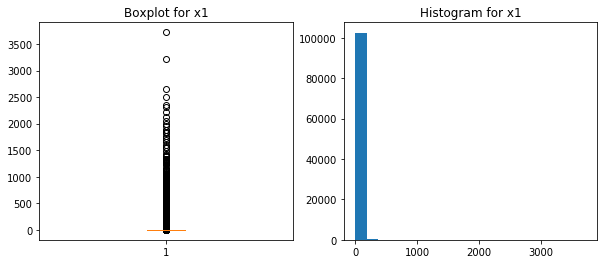

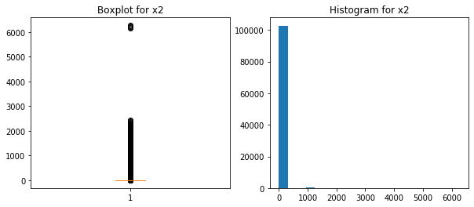

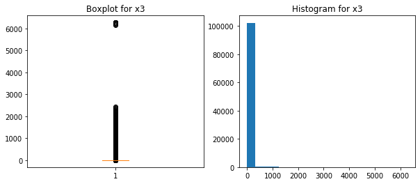

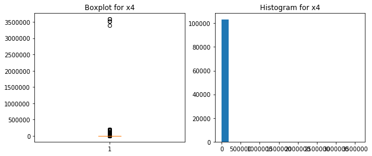

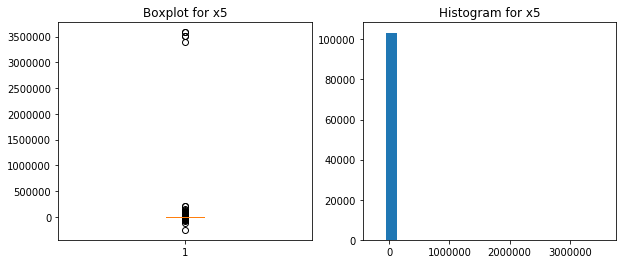

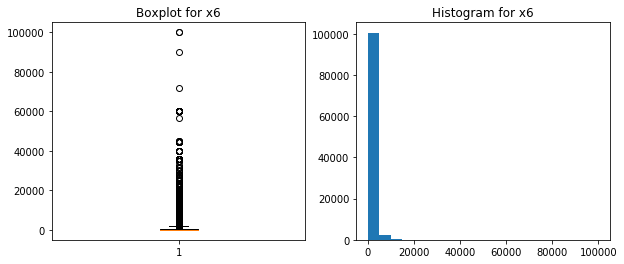

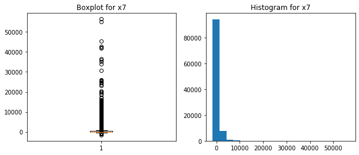

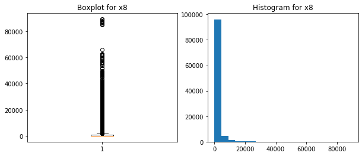

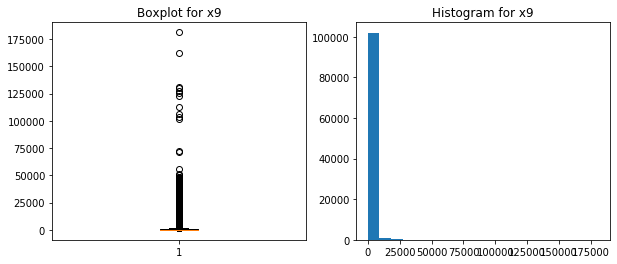

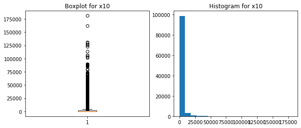

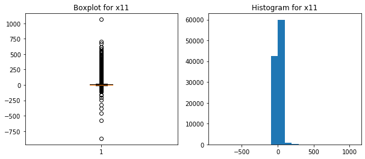

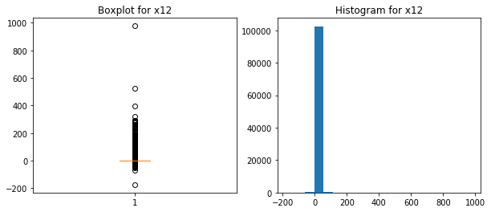

[14 more figures not shown]

```python
fc.boxplots_data(data2)
```

3.1 Estandarización

```python
X_std = StandardScaler().fit_transform(data2)
Xstd = pd.DataFrame(data=X_std,columns=data2.columns)
Xstd.head(5)
```

|  | x1 | x2 | x3 | x4 | x5 | x6 | x7 | x8 | x9 | x10 | x11 | x12 | x13 | x14 | x15 | x16 | x17 | x18 | x19 | x20 | x21 | x22 | x23 | x24 | x25 | x26 |
| --- | --- | --- | --- | --- | --- | --- | --- | --- | --- | --- | --- | --- | --- | --- | --- | --- | --- | --- | --- | --- | --- | --- | --- | --- | --- | --- |
| 0 | -0.099773 | -0.069350 | -0.113145 | 0.169482 | -0.005596 | 0.881023 | 0.165837 | 0.265770 | -0.250576 | 0.044120 | -0.210650 | -0.228086 | -0.122217 | -0.211608 | -0.953243 | -0.895626 | 1.009227 | -0.146748 | -0.041532 | -0.044003 | -0.036761 | 1.249963 | -0.514167 | -0.202294 | -0.182908 | -0.134423 |
| 1 | 1.000716 | -0.035199 | -0.085526 | 0.250706 | -0.009698 | -0.259583 | -0.200376 | -0.280348 | 2.925493 | 1.526878 | 3.071165 | 0.667334 | 3.632350 | 3.205359 | -0.268439 | -0.895626 | 1.293169 | -0.199705 | 0.197498 | 0.189438 | 1.067974 | 0.027099 | 1.068559 | 0.849567 | 0.901814 | 1.863255 |
| 2 | -0.099773 | -0.069350 | -0.113145 | -0.043214 | -0.008439 | -0.085426 | 0.105520 | -0.274552 | -0.193508 | -0.312677 | -0.210650 | -0.100169 | -0.180882 | -0.164150 | -0.268439 | -1.183810 | -0.265051 | -2.126918 | -0.046964 | -0.049864 | -0.061810 | -0.584333 | -1.041742 | -0.111697 | -0.138027 | -0.018768 |
| 3 | -0.099773 | -0.069350 | -0.113145 | -0.050707 | -0.015751 | -0.173731 | -0.049582 | -0.332214 | -0.275567 | -0.402869 | -0.349318 | -0.100169 | -0.356878 | -0.306524 | 1.101169 | 0.833478 | 0.081220 | -1.788872 | -0.029755 | -0.032866 | 0.092726 | -0.788144 | 1.068559 | -0.237591 | -0.262762 | 0.110029 |
| 4 | -0.099773 | -0.069350 | -0.113145 | -0.071544 | -0.029968 | -0.345435 | -0.351169 | -0.338011 | -0.284519 | -0.412571 | -0.395541 | -0.228086 | -0.356878 | -0.353982 | -0.953243 | -0.895626 | 2.629775 | -1.568216 | -0.070404 | -0.072505 | -0.136474 | 1.317900 | -1.041742 | -0.239944 | -0.265093 | -0.294763 |

4. Depuración de variables por correlación

Revisamos correlaciones de Pearson

```python
corr = data2.corr()
corr.to_excel("matriz_correlaciones.xlsx")
corr
```

|  | x1 | x2 | x3 | x4 | x5 | x6 | x7 | x8 | x9 | x10 | x11 | x12 | x13 | x14 | x15 | x16 | x17 | x18 | x19 | x20 | x21 | x22 | x23 | x24 | x25 | x26 |
| --- | --- | --- | --- | --- | --- | --- | --- | --- | --- | --- | --- | --- | --- | --- | --- | --- | --- | --- | --- | --- | --- | --- | --- | --- | --- | --- |
| x1 | 1.000000 | 0.009210 | 0.010089 | 0.016530 | 0.002210 | 0.068262 | 0.021694 | 0.119197 | -0.013393 | 0.078242 | 0.070040 | 0.052375 | 0.060934 | 0.051474 | 0.028011 | -0.016814 | 0.042713 | -0.014696 | 0.003813 | 0.003485 | 0.024381 | 0.002329 | -0.022734 | -0.039068 | -0.004522 | 0.083565 |
| x2 | 0.009210 | 1.000000 | 0.808362 | -0.002407 | -0.000553 | -0.014169 | -0.013304 | -0.017179 | -0.018600 | -0.023416 | -0.029914 | -0.013618 | -0.029066 | -0.058520 | 0.137395 | -0.019964 | 0.021207 | -0.009416 | -0.002999 | -0.002862 | -0.004160 | 0.000167 | 0.001193 | -0.016422 | -0.017803 | -0.017560 |
| x3 | 0.010089 | 0.808362 | 1.000000 | 0.026704 | 0.029431 | -0.016083 | -0.013779 | -0.014283 | -0.024720 | -0.024941 | -0.025884 | -0.015856 | -0.022190 | -0.056566 | 0.187545 | -0.027375 | 0.028235 | -0.013734 | -0.004267 | -0.004189 | -0.005403 | -0.001624 | 0.004316 | -0.023011 | -0.024570 | -0.021329 |
| x4 | 0.016530 | -0.002407 | 0.026704 | 1.000000 | 0.988590 | 0.115418 | 0.090220 | 0.085054 | 0.035637 | 0.082547 | 0.065268 | 0.056042 | 0.048277 | 0.057621 | 0.013229 | -0.024724 | 0.033494 | -0.019311 | 0.006497 | 0.006046 | 0.018293 | 0.002257 | -0.010740 | 0.030046 | 0.036118 | 0.042306 |
| x5 | 0.002210 | -0.000553 | 0.029431 | 0.988590 | 1.000000 | 0.039139 | 0.048613 | 0.014889 | 0.009108 | 0.016147 | 0.012619 | 0.008344 | 0.010769 | 0.011559 | 0.016956 | -0.011792 | 0.015345 | -0.006498 | 0.002655 | 0.002610 | 0.004041 | 0.001708 | -0.002801 | 0.007093 | 0.008467 | 0.007574 |
| x6 | 0.068262 | -0.014169 | -0.016083 | 0.115418 | 0.039139 | 1.000000 | 0.766985 | 0.487327 | 0.192092 | 0.465815 | 0.336466 | 0.217640 | 0.290613 | 0.294313 | -0.028386 | -0.088021 | 0.162482 | -0.071725 | 0.036452 | 0.035508 | 0.079219 | 0.006522 | -0.029012 | 0.144009 | 0.176010 | 0.174317 |
| x7 | 0.021694 | -0.013304 | -0.013779 | 0.090220 | 0.048613 | 0.766985 | 1.000000 | 0.207118 | 0.190080 | 0.262092 | 0.232884 | 0.138438 | 0.206458 | 0.218693 | -0.017158 | -0.075339 | 0.176722 | -0.064539 | 0.051291 | 0.049693 | 0.072110 | 0.003506 | -0.016363 | 0.140923 | 0.165187 | 0.131745 |
| x8 | 0.119197 | -0.017179 | -0.014283 | 0.085054 | 0.014889 | 0.487327 | 0.207118 | 1.000000 | 0.149802 | 0.811366 | 0.461998 | 0.229877 | 0.439223 | 0.364861 | 0.015528 | -0.074604 | 0.118510 | -0.071386 | 0.015324 | 0.014458 | 0.087124 | -0.014606 | -0.057807 | 0.094123 | 0.119802 | 0.217385 |
| x9 | -0.013393 | -0.018600 | -0.024720 | 0.035637 | 0.009108 | 0.192092 | 0.190080 | 0.149802 | 1.000000 | 0.699487 | 0.693715 | 0.287285 | 0.643474 | 0.696697 | -0.007074 | 0.000052 | 0.113636 | 0.020510 | 0.059276 | 0.054593 | 0.066240 | -0.000816 | 0.005582 | 0.718586 | 0.720386 | 0.197510 |
| x10 | 0.078242 | -0.023416 | -0.024941 | 0.082547 | 0.016147 | 0.465815 | 0.262092 | 0.811366 | 0.699487 | 1.000000 | 0.744067 | 0.336006 | 0.697901 | 0.675620 | 0.007047 | -0.053900 | 0.152855 | -0.039477 | 0.046123 | 0.042728 | 0.102137 | -0.011045 | -0.038485 | 0.492867 | 0.512493 | 0.273903 |
| x11 | 0.070040 | -0.029914 | -0.025884 | 0.065268 | 0.012619 | 0.336466 | 0.232884 | 0.461998 | 0.693715 | 0.744067 | 1.000000 | 0.618460 | 0.917352 | 0.970186 | 0.004678 | -0.035054 | 0.131517 | -0.010771 | 0.055208 | 0.052331 | 0.085115 | -0.016643 | -0.018111 | 0.610634 | 0.624110 | 0.347414 |
| x12 | 0.052375 | -0.013618 | -0.015856 | 0.056042 | 0.008344 | 0.217640 | 0.138438 | 0.229877 | 0.287285 | 0.336006 | 0.618460 | 1.000000 | 0.300248 | 0.602746 | -0.007157 | -0.018545 | 0.084825 | -0.007257 | 0.057757 | 0.055603 | 0.081151 | 0.002769 | -0.024835 | 0.221702 | 0.237460 | 0.320304 |
| x13 | 0.060934 | -0.029066 | -0.022190 | 0.048277 | 0.010769 | 0.290613 | 0.206458 | 0.439223 | 0.643474 | 0.697901 | 0.917352 | 0.300248 | 1.000000 | 0.889430 | 0.012272 | -0.023147 | 0.115069 | 0.004167 | 0.041565 | 0.039013 | 0.062019 | -0.025413 | -0.008970 | 0.653217 | 0.661430 | 0.282486 |
| x14 | 0.051474 | -0.058520 | -0.056566 | 0.057621 | 0.011559 | 0.294313 | 0.218693 | 0.364861 | 0.696697 | 0.675620 | 0.970186 | 0.602746 | 0.889430 | 1.000000 | -0.023421 | -0.025658 | 0.120830 | -0.000574 | 0.052989 | 0.050393 | 0.073321 | -0.012491 | -0.013556 | 0.617712 | 0.628485 | 0.326925 |
| x15 | 0.028011 | 0.137395 | 0.187545 | 0.013229 | 0.016956 | -0.028386 | -0.017158 | 0.015528 | -0.007074 | 0.007047 | 0.004678 | -0.007157 | 0.012272 | -0.023421 | 1.000000 | -0.067109 | 0.226206 | -0.019748 | -0.005115 | -0.002574 | 0.007045 | -0.049114 | -0.000481 | -0.006385 | -0.008067 | -0.008437 |
| x16 | -0.016814 | -0.019964 | -0.027375 | -0.024724 | -0.011792 | -0.088021 | -0.075339 | -0.074604 | 0.000052 | -0.053900 | -0.035054 | -0.018545 | -0.023147 | -0.025658 | -0.067109 | 1.000000 | -0.145139 | 0.623769 | -0.000587 | 0.002332 | -0.046712 | 0.038410 | 0.091830 | -0.003766 | -0.007417 | 0.037183 |
| x17 | 0.042713 | 0.021207 | 0.028235 | 0.033494 | 0.015345 | 0.162482 | 0.176722 | 0.118510 | 0.113636 | 0.152855 | 0.131517 | 0.084825 | 0.115069 | 0.120830 | 0.226206 | -0.145139 | 1.000000 | -0.113023 | 0.015628 | 0.013459 | 0.053265 | -0.003962 | -0.062398 | 0.069754 | 0.085463 | 0.123232 |
| x18 | -0.014696 | -0.009416 | -0.013734 | -0.019311 | -0.006498 | -0.071725 | -0.064539 | -0.071386 | 0.020510 | -0.039477 | -0.010771 | -0.007257 | 0.004167 | -0.000574 | -0.019748 | 0.623769 | -0.113023 | 1.000000 | 0.002491 | 0.006898 | -0.027200 | 0.033213 | 0.079500 | 0.021583 | 0.015914 | 0.043403 |
| x19 | 0.003813 | -0.002999 | -0.004267 | 0.006497 | 0.002655 | 0.036452 | 0.051291 | 0.015324 | 0.059276 | 0.046123 | 0.055208 | 0.057757 | 0.041565 | 0.052989 | -0.005115 | -0.000587 | 0.015628 | 0.002491 | 1.000000 | 0.913357 | 0.287661 | -0.005952 | -0.012447 | 0.061718 | 0.062048 | 0.016127 |
| x20 | 0.003485 | -0.002862 | -0.004189 | 0.006046 | 0.002610 | 0.035508 | 0.049693 | 0.014458 | 0.054593 | 0.042728 | 0.052331 | 0.055603 | 0.039013 | 0.050393 | -0.002574 | 0.002332 | 0.013459 | 0.006898 | 0.913357 | 1.000000 | 0.239606 | -0.005406 | -0.010089 | 0.057065 | 0.057325 | 0.014739 |
| x21 | 0.024381 | -0.004160 | -0.005403 | 0.018293 | 0.004041 | 0.079219 | 0.072110 | 0.087124 | 0.066240 | 0.102137 | 0.085115 | 0.081151 | 0.062019 | 0.073321 | 0.007045 | -0.046712 | 0.053265 | -0.027200 | 0.287661 | 0.239606 | 1.000000 | -0.021134 | -0.016544 | 0.058275 | 0.064418 | 0.063950 |
| x22 | 0.002329 | 0.000167 | -0.001624 | 0.002257 | 0.001708 | 0.006522 | 0.003506 | -0.014606 | -0.000816 | -0.011045 | -0.016643 | 0.002769 | -0.025413 | -0.012491 | -0.049114 | 0.038410 | -0.003962 | 0.033213 | -0.005952 | -0.005406 | -0.021134 | 1.000000 | -0.034774 | -0.006230 | -0.001446 | -0.000859 |
| x23 | -0.022734 | 0.001193 | 0.004316 | -0.010740 | -0.002801 | -0.029012 | -0.016363 | -0.057807 | 0.005582 | -0.038485 | -0.018111 | -0.024835 | -0.008970 | -0.013556 | -0.000481 | 0.091830 | -0.062398 | 0.079500 | -0.012447 | -0.010089 | -0.016544 | -0.034774 | 1.000000 | 0.013827 | 0.010461 | -0.054977 |
| x24 | -0.039068 | -0.016422 | -0.023011 | 0.030046 | 0.007093 | 0.144009 | 0.140923 | 0.094123 | 0.718586 | 0.492867 | 0.610634 | 0.221702 | 0.653217 | 0.617712 | -0.006385 | -0.003766 | 0.069754 | 0.021583 | 0.061718 | 0.057065 | 0.058275 | -0.006230 | 0.013827 | 1.000000 | 0.994249 | 0.181100 |
| x25 | -0.004522 | -0.017803 | -0.024570 | 0.036118 | 0.008467 | 0.176010 | 0.165187 | 0.119802 | 0.720386 | 0.512493 | 0.624110 | 0.237460 | 0.661430 | 0.628485 | -0.008067 | -0.007417 | 0.085463 | 0.015914 | 0.062048 | 0.057325 | 0.064418 | -0.001446 | 0.010461 | 0.994249 | 1.000000 | 0.201988 |
| x26 | 0.083565 | -0.017560 | -0.021329 | 0.042306 | 0.007574 | 0.174317 | 0.131745 | 0.217385 | 0.197510 | 0.273903 | 0.347414 | 0.320304 | 0.282486 | 0.326925 | -0.008437 | 0.037183 | 0.123232 | 0.043403 | 0.016127 | 0.014739 | 0.063950 | -0.000859 | -0.054977 | 0.181100 | 0.201988 | 1.000000 |

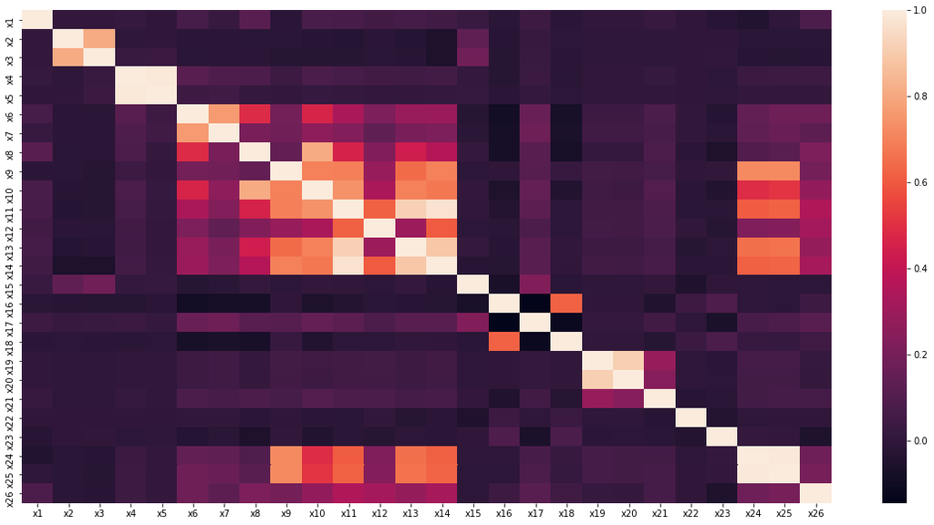

```python
# Se grafica la matriz de correlaciones
plt.figure(figsize=(20, 10))
sns.heatmap(corr, annot=False)
plt.show()
```

Luego se realiza un análisis por correlación de Pearson a través de la matriz y un mapa de calor que muestra que de las variables X6 a la X14 hay una concentración de correlaciones directas de un valor cercano a 1. Así mismo, se observa que las variables X4 y X5 tienen una correlación del 100% al igual que las variables X24 y X25.

4.1. Depuración de variables por correlación

Se sacan correlaciones entre cada par de variables para descartar aquellas que estén correlacionadas con un valor mayor al 70%. Para el proceso de depuración se tiene en cuenta los siguientes criterios:  
Si dos variables están correlacionadas y una de ellas tiene mayor correlacion respecto al resto de variables, se elimina. Este proceso se realiza de manera individual para cada una de las variables, es decir, se elimina solo una variable a la vez.

```python
det, data3 = fc.depuracion_correlaciones(data2)
```

```
Iniciando depuración de variables por correlaciones

Correlaciones multiples:

         x1        x2        x3        x4        x5        x6        x7   x8  \
0  0.115936  0.655033  0.661514  0.986434  0.986244  0.735007  0.642008  1.0

    x9  x10       x11       x12       x13       x14       x15       x16  \
0  1.0  1.0  0.987594  0.885477  0.971263  0.951799  0.107071  0.403013

        x17       x18       x19       x20       x21       x22       x23  \
0  0.137437  0.395987  0.839371  0.834871  0.102582  0.012575  0.019541

        x24       x25       x26
0  0.991209  0.991245  0.182523


Calculando correlaciones de Pearson
Pares correlacionados:

  variable1 variable2  correlacion
0       x24       x25       0.9942


Variable eliminada: x25


===================================================================================


Iniciando depuración de variables por correlaciones

Correlaciones multiples:

         x1        x2        x3        x4        x5        x6       x7   x8  \
0  0.030343  0.655031  0.661511  0.986209  0.986019  0.733947  0.64119  1.0

    x9  x10       x11       x12       x13       x14    x15       x16  \
0  1.0  1.0  0.987591  0.885369  0.971256  0.951799  0.106  0.402684

```

[output cut: 195 more lines]

```
        x22      x23       x24       x26
0  0.007062  0.01864  0.601052  0.163914


Calculando correlaciones de Pearson
Pares correlacionados:

  variable1 variable2  correlacion
0        x9       x24       0.7186


Variable eliminada: x24


===================================================================================
```

```python
corr2 = data3.corr()
corr2.to_excel("matriz_correlaciones_depurada.xlsx")
```

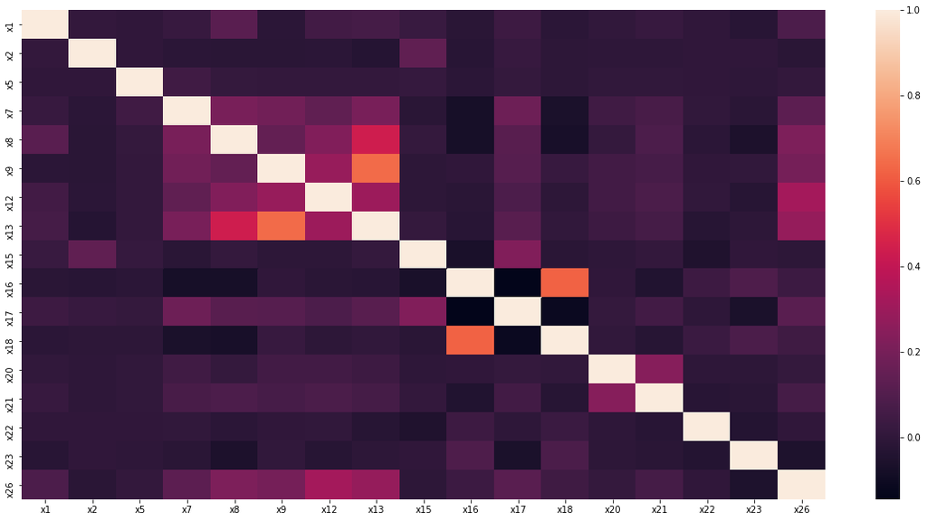

```python
# Se grafica la matriz de correlaciones
plt.figure(figsize=(20, 10))
sns.heatmap(corr2, annot=False)
plt.show()
```

Representación logaritmica del determinante de la matriz de covarianzas vs el número de variables eliminadas

```
<function matplotlib.pyplot.show(*args, **kw)>
```

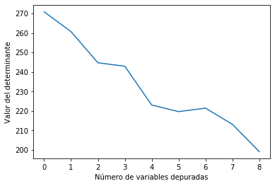

```python
plt.plot(np.log(det))
plt.xlabel('Número de variables depuradas')
plt.ylabel('Valor del determinante')
plt.show
```

Revisamos la correlación multiple de las variables

```python
fc.correlacion_multiple(data3)
```

|  | x1 | x2 | x5 | x7 | x8 | x9 | x12 | x13 | x15 | x16 | x17 | x18 | x20 | x21 | x22 | x23 | x26 |
| --- | --- | --- | --- | --- | --- | --- | --- | --- | --- | --- | --- | --- | --- | --- | --- | --- | --- |
| 0 | 0.022363 | 0.020256 | 0.00277 | 0.101431 | 0.272406 | 0.459141 | 0.18007 | 0.545913 | 0.078681 | 0.400616 | 0.119603 | 0.393448 | 0.061263 | 0.07277 | 0.007034 | 0.018559 | 0.163741 |

4.2. Reducción de dimensionalidad por autovalores

En esta sección se sacan los autovalores de cada una de las variables, con el objetivo de encontrar las variables cuyos autovalores contienen la mayor varianza respecto a la varianza total y eliminar aquellas variables cuya varianza es despreciable. Esto se realiza para reducir la dimensionalidad del dataset. Como criterios para la reducción de la dimensionalidad del dataset se revisan los siguientes:

Criterio de la varianza explicada, de variables cuya varianza sea despreciable con respecto a la varianza total. Buscando mantener al menos el 90% de la varianza.

Criterio del valor propio (Kaiser), buscando mantener las variables cuyos autovalores se encuentren por encima de la media.

Gráfico de sedimentación (screeplot), en el cual se busca encontrar el "codo" o punto de inflexión en el cual los autovalores cambian bruscamente.

**Reducción por criterio de la varianza explicada**

```python
S = data3.cov()
autovalores, autovectores = np.linalg.eig(S)
aux = pd.DataFrame()
aux["autovalor"] = np.absolute(autovalores)
```

```python
#  Hacemos una lista de parejas (autovector, autovalor)
auto_pares = [(np.abs(autovalores[i]), autovectores[:,i]) for i in range(len(autovalores))]
# Ordenamos estas parejas den orden descendiente con la función sort
auto_pares.sort(key=lambda x: x[0], reverse=True)
```

```python
aux.sort_values(by="autovalor", ascending=False).head(5)
```

|  | autovalor |
| --- | --- |
| 0 | 1.888614e+10 |
| 1 | 2.779325e+09 |
| 2 | 6.060585e+08 |
| 3 | 1.122253e+07 |
| 4 | 6.806268e+06 |

```python
aux["% Varianza"] = (aux[["autovalor"]]/(aux[["autovalor"]].sum()))*100
```

```python
aux.sort_values(by="% Varianza", ascending=False).round(4)
```

|  | autovalor | % Varianza |
| --- | --- | --- |
| 0 | 1.888614e+10 | 84.7049 |
| 1 | 2.779325e+09 | 12.4654 |
| 2 | 6.060585e+08 | 2.7182 |
| 3 | 1.122253e+07 | 0.0503 |
| 4 | 6.806268e+06 | 0.0305 |
| 5 | 5.056605e+06 | 0.0227 |
| 6 | 1.233620e+06 | 0.0055 |
| 7 | 5.268880e+05 | 0.0024 |
| 8 | 1.957988e+04 | 0.0001 |
| 9 | 7.701908e+03 | 0.0000 |
| 10 | 2.911093e+03 | 0.0000 |
| 11 | 2.166315e+02 | 0.0000 |
| 12 | 1.322934e+02 | 0.0000 |
| 13 | 5.005650e+01 | 0.0000 |
| 14 | 7.276200e+00 | 0.0000 |
| 16 | 3.519000e+00 | 0.0000 |
| 15 | 1.962400e+00 | 0.0000 |

```python
aux_ordenado = aux[["% Varianza"]].sort_values(by="% Varianza", ascending=False)
aux_ordenado["% Varianza acumulada"] = np.cumsum(aux_ordenado[["% Varianza"]])
aux_ordenado
```

|  | % Varianza | % Varianza acumulada |
| --- | --- | --- |
| 0 | 8.470488e+01 | 84.704885 |
| 1 | 1.246535e+01 | 97.170238 |
| 2 | 2.718190e+00 | 99.888428 |
| 3 | 5.033338e-02 | 99.938761 |
| 4 | 3.052631e-02 | 99.969288 |
| 5 | 2.267902e-02 | 99.991967 |
| 6 | 5.532823e-03 | 99.997500 |
| 7 | 2.363108e-03 | 99.999863 |
| 8 | 8.781632e-05 | 99.999951 |
| 9 | 3.454328e-05 | 99.999985 |
| 10 | 1.305634e-05 | 99.999998 |
| 11 | 9.715986e-07 | 99.999999 |
| 12 | 5.933395e-07 | 100.000000 |
| 13 | 2.245047e-07 | 100.000000 |
| 14 | 3.263401e-08 | 100.000000 |
| 16 | 1.578267e-08 | 100.000000 |
| 15 | 8.801372e-09 | 100.000000 |

**Reducción por el valor propio (Kaiser)**

```python
AVmean = aux[["autovalor"]].mean()
AVmean
```

```
autovalor    1.311553e+09
dtype: float64
```

```python
aux[aux["autovalor"]>AVmean[0]].sort_values(by="% Varianza",ascending=False)
```

|  | autovalor | % Varianza |
| --- | --- | --- |
| 0 | 1.888614e+10 | 84.704885 |
| 1 | 2.779325e+09 | 12.465354 |

Del resultado anterior se observa que las primeras 2 componentes se encuentran por encima de la media.

**Reducción por el punto critico (diagrama de codo)**

```
<function matplotlib.pyplot.show(*args, **kw)>
```

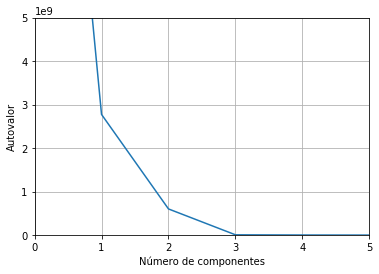

```python
plt.plot(aux[["autovalor"]].sort_values(by="autovalor",ascending=False).values)
plt.xlabel('Número de componentes')
plt.ylabel('Autovalor')
plt.xlim([0, 5])
plt.ylim([0, 0.5e10])
plt.grid()
plt.show
```

Del resultado anterior se encuentra que el punto de inflexión se encuentra aproximadamente en 2 componentes

Despues de validar los criterios definidos anteriormente se encuentra que el número de componentes óptimo que conserva más del 95% de la varianza de los datos es 2.

```python
data3.shape
```

```
(103323, 17)
```

```python
#Generamos la matríz a partir de los pares autovalor-autovector
matrix_w = np.hstack((auto_pares[0][1].reshape(17,1),
                      auto_pares[1][1].reshape(17,1)))
Y = data3.dot(matrix_w)
```

```python
matrix_w.shape
```

```
(17, 2)
```

```python
Y.head(5)
```

|  | 0 | 1 |
| --- | --- | --- |
| 0 | -18302.663703 | 488.568261 |
| 1 | -169797.379008 | 4677.327226 |
| 2 | -14862.787725 | 425.635973 |
| 3 | -35956.927270 | 1863.355998 |
| 4 | -4580.540202 | 514.089049 |

```python
Ydf = pd.DataFrame(data=Y.values,columns=["C1","C2"])
Ydf.head(5)
```

|  | C1 | C2 |
| --- | --- | --- |
| 0 | -18302.663703 | 488.568261 |
| 1 | -169797.379008 | 4677.327226 |
| 2 | -14862.787725 | 425.635973 |
| 3 | -35956.927270 | 1863.355998 |
| 4 | -4580.540202 | 514.089049 |

5. K Means

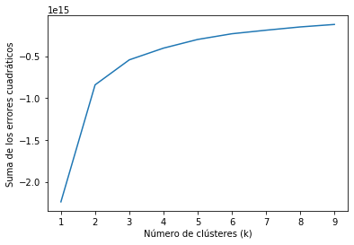

```python
#%% Curva elbow para determinar valor óptimo de k.
nc = range(1, 10) # El número de iteraciones que queremos hacer.
kmeans = [KMeans(n_clusters=i,) for i in nc]
score = [kmeans[i].fit(Ydf).score(Ydf) for i in range(len(kmeans))]
score
plt.xlabel('Número de clústeres (k)')
plt.ylabel('Suma de los errores cuadráticos')
plt.plot(nc,score)
```

```python
kmeans = KMeans(n_clusters=4).fit(Ydf)
C = kmeans.cluster_centers_
labels = kmeans.labels_
print(C)
```

```
[[-1.99085758e+04 -5.21059432e+02]
 [-6.26356077e+06  3.72974678e+05]
 [-3.64550246e+05 -2.11249918e+06]
 [-2.02954179e+06 -2.96136437e+05]]
```

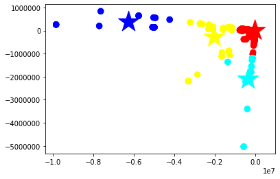

```python
# Getting the values and plotting it
f1 = Ydf['C1'].values
f2 = Ydf['C2'].values

asignar=[]
colores=['red','blue','cyan','yellow']

for row in labels:
    asignar.append(colores[row])

plt.scatter(f1, f2, c=asignar, s=70)
plt.scatter(C[:, 0], C[:, 1], marker='*', c=colores, s=1000)
plt.show()
```

```python
Datacopy = data.copy()
Datacopy.iloc[:, 6:32].head(5)
```

|  | x1 | x2 | x3 | x4 | x5 | x6 | x7 | x8 | x9 | x10 | x11 | x12 | x13 | x14 | x15 | x16 | x17 | x18 | x19 | x20 | x21 | x22 | x23 | x24 | x25 | x26 |
| --- | --- | --- | --- | --- | --- | --- | --- | --- | --- | --- | --- | --- | --- | --- | --- | --- | --- | --- | --- | --- | --- | --- | --- | --- | --- | --- |
| 0 | 0 | 0 | 0 | 750 | 600 | 600 | 600 | 3 | 468 | 471 | 6 | 0 | 5 | 6 | 1 | 10 | 297 | 6820 | 731 | 878 | 8776 | 22 | 6 | 480 | 480 | 144 |
| 1 | -1 | 0 | 0 | 1250 | 500 | 500 | 500 | 1222 | 0 | 1222 | 1 | 0 | 1 | 0 | 1 | 3 | 27 | 4290 | 2010 | 2081 | 24130 | 19 | 5 | 0 | 0 | 0 |
| 2 | 0 | 0 | 0 | 0 | -10 | 0 | 0 | 0 | 34 | 34 | 0 | 0 | 0 | 0 | 0 | 10 | 11 | 7110 | 0 | 0 | 0 | 53 | 2 | 30 | 30 | 1 |
| 3 | 0 | 0 | 0 | 0 | -10 | 0 | 0 | 0 | 182 | 182 | 2 | 0 | 1 | 2 | 3 | 3 | 109 | 4322 | 416 | 492 | 807 | 34 | 6 | 89 | 89 | 0 |
| 4 | -1 | 0 | 0 | 0 | -10 | 0 | 0 | 0 | 0 | 0 | 0 | 0 | 0 | 0 | 0 | 10 | 335 | 6810 | 0 | 0 | 0 | 53 | 2 | 0 | 0 | 0 |

```python
Datacopy["Cluster"] = kmeans.predict(Ydf)
```

```python
Datacopy.groupby('Cluster').size()
```

```
Cluster
0    103179
1        35
2        36
3        73
dtype: int64
```

```python
kmeans = KMeans(n_clusters=3).fit(Ydf)
C = kmeans.cluster_centers_
labels = kmeans.labels_
print(C)
```

```
[[-1.99282172e+04 -6.94768671e+02]
 [-6.26356077e+06  3.72974678e+05]
 [-1.67341873e+06 -8.39316399e+05]]
```

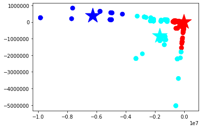

```python
# Getting the values and plotting it
f1 = Ydf['C1'].values
f2 = Ydf['C2'].values

asignar=[]
colores=['red','blue','cyan']

for row in labels:
    asignar.append(colores[row])

plt.scatter(f1, f2, c=asignar, s=70)
plt.scatter(C[:, 0], C[:, 1], marker='*', c=colores, s=1000)
plt.show()
```

```python
Datacopy["Cluster"] = kmeans.predict(Ydf)
```

```python
Datacopy.groupby('Cluster').size()
```

```
Cluster
0    103193
1        35
2        95
dtype: int64
```

```python
kmeans = KMeans(n_clusters=2,algorithm="elkan").fit(Ydf)
C = kmeans.cluster_centers_
labels = kmeans.labels_
print(C)
```

```
[[-2.08809568e+04 -1.35919320e+03]
 [-5.06031414e+06  3.60901044e+04]]
```

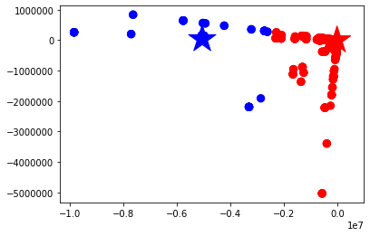

```python
# Getting the values and plotting it
f1 = Ydf['C1'].values
f2 = Ydf['C2'].values

asignar=[]
colores=['red','blue']

for row in labels:
    asignar.append(colores[row])

plt.scatter(f1, f2, c=asignar, s=70)
plt.scatter(C[:, 0], C[:, 1], marker='*', c=colores, s=1000)
plt.show()
```

```python
Datacopy["Cluster"] = kmeans.predict(Ydf)
```

```python
Datacopy.groupby('Cluster').size()
```

```
Cluster
0    103268
1        55
dtype: int64
```

# Revisión Kmeans sin reducción de dimensionalidad

```python
kmeans = KMeans(n_clusters=4).fit(data3)
C = kmeans.cluster_centers_
labels = kmeans.labels_
print(C)
```

```
[[ 5.44465444e+00  6.09810136e+00  7.36992276e+02  4.06554396e+02
   1.10756489e+03  7.59557953e+02  1.77388810e+00  6.07658535e+00
   1.39145563e+00  5.10836507e+00  1.67244139e+02  4.96336585e+03
   2.73681506e+03  1.97243505e+04  3.36118396e+01  3.97574119e+00
   2.24197356e+02]
 [ 8.25714286e+00  7.02857143e+00  1.23342857e+02  1.24485714e+02
   3.95800000e+03  6.57857143e+02 -1.62857143e+00 -1.90571429e+01
   1.65714286e+00  3.14285714e+00  2.01742857e+02  4.05545714e+03
   3.29081114e+05  6.26603506e+06  2.23428571e+01  3.05714286e+00
   1.23657143e+02]
 [-5.88235294e-02  5.32907052e-15  3.47923529e+03  3.24823529e+03
   3.68411765e+02  8.50741176e+03  1.28235294e+01  3.59117647e+01
   1.38235294e+00  7.20588235e+00  2.52852941e+02  6.91126471e+03
   2.17709268e+06  6.26373235e+04  4.23529412e+01  2.88235294e+00
   3.00705882e+02]
 [-1.46666667e-01  1.20000000e-01  8.32266667e+02  6.09813333e+02
   5.63106667e+02  1.75022667e+03  1.10133333e+01  1.35333333e+01
   2.01333333e+00  4.33333333e+00  1.50906667e+02  4.72480000e+03
   5.47352733e+05  1.96307483e+06  2.01333333e+01  3.30666667e+00
   3.50973333e+02]]
```

```python
Datacopy["Cluster"] = kmeans.predict(data3)
```

```python
Datacopy.groupby('Cluster').size()
```

```
Cluster
0    103179
1        35
2        34
3        75
dtype: int64
```

```python
data3.describe().T.round(2)
```

|  | count | mean | std | min | 25% | 50% | 75% | max |
| --- | --- | --- | --- | --- | --- | --- | --- | --- |
| x1 | 103323.0 | 5.44 | 54.52 | -1.0 | 0.0 | 0.0 | 0.0 | 3721.0 |
| x2 | 103323.0 | 6.09 | 87.85 | 0.0 | 0.0 | 0.0 | 0.0 | 6278.0 |
| x5 | 103323.0 | 737.76 | 24618.38 | -253341.0 | -10.0 | 0.0 | 472.0 | 3582706.0 |
| x7 | 103323.0 | 407.54 | 1160.53 | -1560.0 | 0.0 | 0.0 | 350.0 | 56500.0 |
| x8 | 103323.0 | 1107.89 | 3277.69 | -4.0 | 0.0 | 0.0 | 728.0 | 89415.0 |
| x9 | 103323.0 | 762.79 | 2681.00 | -14.0 | 4.0 | 88.0 | 522.0 | 181149.0 |
| x12 | 103323.0 | 1.78 | 7.82 | -174.0 | 0.0 | 0.0 | 1.0 | 978.0 |
| x13 | 103323.0 | 6.08 | 17.05 | -899.0 | 0.0 | 1.0 | 6.0 | 701.0 |
| x15 | 103323.0 | 1.39 | 1.46 | 0.0 | 0.0 | 1.0 | 2.0 | 5.0 |
| x16 | 103323.0 | 5.11 | 3.47 | 0.0 | 2.0 | 3.0 | 10.0 | 10.0 |
| x17 | 103323.0 | 167.27 | 144.40 | 0.0 | 59.0 | 134.0 | 253.0 | 1472.0 |
| x18 | 103323.0 | 4963.53 | 2265.98 | 0.0 | 4290.0 | 4690.0 | 6810.0 | 10000.0 |
| x20 | 103323.0 | 3958.19 | 54592.22 | 0.0 | 24.0 | 629.0 | 2270.0 | 5067583.0 |
| x21 | 103323.0 | 23265.01 | 136693.09 | 0.0 | 456.5 | 7511.0 | 25393.0 | 9819698.0 |
| x22 | 103323.0 | 33.60 | 14.72 | 0.0 | 23.0 | 34.0 | 48.0 | 54.0 |
| x23 | 103323.0 | 3.97 | 1.90 | 1.0 | 2.0 | 4.0 | 6.0 | 9.0 |
| x26 | 103323.0 | 224.28 | 760.89 | 0.0 | 0.0 | 28.0 | 190.0 | 51258.0 |

# Estandarizando

```python
data3std = StandardScaler().fit_transform(data3)
data3std = pd.DataFrame(data=data3std,columns=data3.columns)
data3std.head(5)
```

|  | x1 | x2 | x5 | x7 | x8 | x9 | x12 | x13 | x15 | x16 | x17 | x18 | x20 | x21 | x22 | x23 | x26 |
| --- | --- | --- | --- | --- | --- | --- | --- | --- | --- | --- | --- | --- | --- | --- | --- | --- | --- |
| 0 | -0.099773 | -0.069350 | -0.005596 | 0.165837 | 0.265770 | -0.250576 | -0.228086 | -0.122217 | -0.953243 | -0.895626 | 1.009227 | -0.146748 | -0.044003 | -0.036761 | 1.249963 | -0.514167 | -0.134423 |
| 1 | 1.000716 | -0.035199 | -0.009698 | -0.200376 | -0.280348 | 2.925493 | 0.667334 | 3.632350 | -0.268439 | -0.895626 | 1.293169 | -0.199705 | 0.189438 | 1.067974 | 0.027099 | 1.068559 | 1.863255 |
| 2 | -0.099773 | -0.069350 | -0.008439 | 0.105520 | -0.274552 | -0.193508 | -0.100169 | -0.180882 | -0.268439 | -1.183810 | -0.265051 | -2.126918 | -0.049864 | -0.061810 | -0.584333 | -1.041742 | -0.018768 |
| 3 | -0.099773 | -0.069350 | -0.015751 | -0.049582 | -0.332214 | -0.275567 | -0.100169 | -0.356878 | 1.101169 | 0.833478 | 0.081220 | -1.788872 | -0.032866 | 0.092726 | -0.788144 | 1.068559 | 0.110029 |
| 4 | -0.099773 | -0.069350 | -0.029968 | -0.351169 | -0.338011 | -0.284519 | -0.228086 | -0.356878 | -0.953243 | -0.895626 | 2.629775 | -1.568216 | -0.072505 | -0.136474 | 1.317900 | -1.041742 | -0.294763 |

```python
data3std.describe().T
```

|  | count | mean | std | min | 25% | 50% | 75% | max |
| --- | --- | --- | --- | --- | --- | --- | --- | --- |
| x1 | 103323.0 | -7.990529e-16 | 1.000005 | -0.118114 | -0.099773 | -0.099773 | -0.099773 | 68.148892 |
| x2 | 103323.0 | -1.165155e-15 | 1.000005 | -0.069350 | -0.069350 | -0.069350 | -0.069350 | 71.397664 |
| x5 | 103323.0 | -8.772753e-16 | 1.000005 | -10.320744 | -0.030374 | -0.029968 | -0.010795 | 145.500470 |
| x7 | 103323.0 | 5.938946e-16 | 1.000005 | -1.695386 | -0.351169 | -0.351169 | -0.049582 | 48.333613 |
| x8 | 103323.0 | -7.901255e-16 | 1.000005 | -0.339232 | -0.338011 | -0.338011 | -0.115903 | 26.941967 |
| x9 | 103323.0 | 4.611692e-16 | 1.000005 | -0.289741 | -0.283027 | -0.251695 | -0.089815 | 67.283519 |
| x12 | 103323.0 | -1.143431e-15 | 1.000005 | -22.485670 | -0.228086 | -0.228086 | -0.100169 | 124.874886 |
| x13 | 103323.0 | -1.211528e-16 | 1.000005 | -53.096807 | -0.356878 | -0.298212 | -0.004887 | 40.767361 |
| x15 | 103323.0 | -4.830071e-16 | 1.000005 | -0.953243 | -0.953243 | -0.268439 | 0.416365 | 2.470776 |
| x16 | 103323.0 | 6.114581e-16 | 1.000005 | -1.471994 | -0.895626 | -0.607442 | 1.409846 | 1.409846 |
| x17 | 103323.0 | 3.730508e-17 | 1.000005 | -1.158430 | -0.749830 | -0.230424 | 0.593701 | 9.035788 |
| x18 | 103323.0 | 5.935416e-17 | 1.000005 | -2.190467 | -0.297236 | -0.120711 | 0.814872 | 2.222660 |
| x20 | 103323.0 | -2.966064e-16 | 1.000005 | -0.072505 | -0.072065 | -0.060983 | -0.030924 | 92.754047 |
| x21 | 103323.0 | 1.166689e-16 | 1.000005 | -0.170200 | -0.166860 | -0.115251 | 0.015568 | 71.667707 |
| x22 | 103323.0 | 7.855793e-17 | 1.000005 | -2.282756 | -0.720207 | 0.027099 | 0.978216 | 1.385837 |
| x23 | 103323.0 | -1.418036e-15 | 1.000005 | -1.569317 | -1.041742 | 0.013409 | 1.068559 | 2.651285 |
| x26 | 103323.0 | 6.646091e-16 | 1.000005 | -0.294763 | -0.294763 | -0.257964 | -0.045054 | 67.071678 |

```python
kmeans = KMeans(n_clusters=4).fit(data3std)
C = kmeans.cluster_centers_
labels = kmeans.labels_
print(C)
```

```
[[-1.80440146e-02  2.29080220e-02 -6.69646178e-03 -1.26633331e-02
  -5.23909003e-02 -9.78351153e-02 -5.52878712e-02 -1.04563200e-01
   4.42955464e-02 -6.40752936e-01  9.98806482e-02 -5.65599822e-01
  -2.43745157e-02 -1.59367811e-02 -2.77115677e-02 -4.91625300e-02
  -8.92826804e-02]
 [-9.97728623e-02 -6.93504446e-02  1.42815837e+02 -3.51169358e-01
  -3.38011182e-01 -2.84519204e-01 -2.28086295e-01 -3.56877542e-01
   2.47077620e+00 -8.95625988e-01  3.30535496e-01 -8.40815854e-02
  -5.64623870e-02 -1.55253707e-01  9.50359105e-02  1.34085600e-02
  -2.94763337e-01]
 [ 6.98019231e-01 -5.22031679e-02  8.73979928e-02  1.49861682e+00
   2.23070523e+00  2.15624108e+00  1.69249344e+00  2.58520835e+00
  -3.11685597e-02 -3.75005593e-02  4.92339789e-01  6.10218859e-02
   4.98465803e-01  8.44985787e-01  6.33329601e-02 -1.99669535e-01
   1.74483885e+00]
 [-6.42009860e-02 -3.47535227e-02 -2.04564984e-02 -1.85674495e-01
  -2.14846890e-01 -1.21068444e-01 -1.34498172e-01 -1.68524923e-01
  -7.73043753e-02  1.18132004e+00 -2.52008132e-01  1.02953820e+00
  -2.47634118e-02 -8.85532553e-02  4.20137555e-02  1.18066903e-01
  -7.93975253e-02]]
```

```python
Datacopy["Cluster"] = kmeans.predict(data3std)
```

```python
Datacopy.groupby('Cluster').size()
```

```
Cluster
0    63748
1        5
2     4835
3    34735
dtype: int64
```

```python
kmeans = KMeans(n_clusters=3).fit(data3std)
C = kmeans.cluster_centers_
labels = kmeans.labels_
print(C)
```

```
[[-0.06420508 -0.03475751 -0.02045663 -0.18567291 -0.21471499 -0.12099641
  -0.13437269 -0.16843852 -0.07732639  1.18133806 -0.25196517  1.02951709
  -0.02476142 -0.08853354  0.04196901  0.1179941  -0.0789154 ]
 [-0.01805199  0.02289934 -0.00669806 -0.01268288 -0.05223916 -0.09772916
  -0.05524394 -0.10437161  0.0442876  -0.64070459  0.09989139 -0.56562437
  -0.02437406 -0.01592514 -0.02768723 -0.04922285 -0.08919094]
 [ 0.69884753 -0.05218545  0.23513358  1.5002181   2.22995751  2.15648357
   1.69270684  2.58463543 -0.0283755  -0.03941334  0.4928248   0.06132327
   0.49895303  0.84549667  0.06349679 -0.19858117  1.74184346]]
```

```python
Datacopy["Cluster"] = kmeans.predict(data3std)
```

```python
data3std.shape
```

```
(103323, 17)
```

```python
Datacopy.groupby('Cluster').size()
```

```
Cluster
0    34741
1    63757
2     4825
dtype: int64
```

```python
kmeans = KMeans(n_clusters=2).fit(data3std)
C = kmeans.cluster_centers_
labels = kmeans.labels_
print(C)
```

```
[[-0.05158914 -0.0353625  -0.01931257 -0.16920686 -0.1853229  -0.0642207
  -0.08088933 -0.10904555 -0.07646907  1.18810742 -0.23772219  1.03313449
  -0.01141554 -0.0798519   0.04451442  0.11900074  0.02590144]
 [ 0.02708289  0.01856435  0.01013857  0.08882898  0.09728946  0.03371411
   0.04246469  0.05724594  0.04014417 -0.62372396  0.12479766 -0.5423674
   0.00599285  0.04192007 -0.02336886 -0.06247214 -0.01359755]]
```

```python
Datacopy["Cluster"] = kmeans.predict(data3std)
```

```python
Datacopy.groupby('Cluster').size()
```

```
Cluster
0    35588
1    67735
dtype: int64
```

# Escalado

```python
data3scale = scale(data3)
data3scale = pd.DataFrame(data=data3scale,columns=data3.columns)
data3scale.head(5)
```

|  | x1 | x2 | x5 | x7 | x8 | x9 | x12 | x13 | x15 | x16 | x17 | x18 | x20 | x21 | x22 | x23 | x26 |
| --- | --- | --- | --- | --- | --- | --- | --- | --- | --- | --- | --- | --- | --- | --- | --- | --- | --- |
| 0 | -0.099773 | -0.069350 | -0.005596 | 0.165837 | 0.265770 | -0.250576 | -0.228086 | -0.122217 | -0.953243 | -0.895626 | 1.009227 | -0.146748 | -0.044003 | -0.036761 | 1.249963 | -0.514167 | -0.134423 |
| 1 | 1.000716 | -0.035199 | -0.009698 | -0.200376 | -0.280348 | 2.925493 | 0.667334 | 3.632350 | -0.268439 | -0.895626 | 1.293169 | -0.199705 | 0.189438 | 1.067974 | 0.027099 | 1.068559 | 1.863255 |
| 2 | -0.099773 | -0.069350 | -0.008439 | 0.105520 | -0.274552 | -0.193508 | -0.100169 | -0.180882 | -0.268439 | -1.183810 | -0.265051 | -2.126918 | -0.049864 | -0.061810 | -0.584333 | -1.041742 | -0.018768 |
| 3 | -0.099773 | -0.069350 | -0.015751 | -0.049582 | -0.332214 | -0.275567 | -0.100169 | -0.356878 | 1.101169 | 0.833478 | 0.081220 | -1.788872 | -0.032866 | 0.092726 | -0.788144 | 1.068559 | 0.110029 |
| 4 | -0.099773 | -0.069350 | -0.029968 | -0.351169 | -0.338011 | -0.284519 | -0.228086 | -0.356878 | -0.953243 | -0.895626 | 2.629775 | -1.568216 | -0.072505 | -0.136474 | 1.317900 | -1.041742 | -0.294763 |

```python
data3scale.describe().T
```

|  | count | mean | std | min | 25% | 50% | 75% | max |
| --- | --- | --- | --- | --- | --- | --- | --- | --- |
| x1 | 103323.0 | -7.990529e-16 | 1.000005 | -0.118114 | -0.099773 | -0.099773 | -0.099773 | 68.148892 |
| x2 | 103323.0 | -1.165155e-15 | 1.000005 | -0.069350 | -0.069350 | -0.069350 | -0.069350 | 71.397664 |
| x5 | 103323.0 | -8.772753e-16 | 1.000005 | -10.320744 | -0.030374 | -0.029968 | -0.010795 | 145.500470 |
| x7 | 103323.0 | 5.938946e-16 | 1.000005 | -1.695386 | -0.351169 | -0.351169 | -0.049582 | 48.333613 |
| x8 | 103323.0 | -7.901255e-16 | 1.000005 | -0.339232 | -0.338011 | -0.338011 | -0.115903 | 26.941967 |
| x9 | 103323.0 | 4.611692e-16 | 1.000005 | -0.289741 | -0.283027 | -0.251695 | -0.089815 | 67.283519 |
| x12 | 103323.0 | -1.143431e-15 | 1.000005 | -22.485670 | -0.228086 | -0.228086 | -0.100169 | 124.874886 |
| x13 | 103323.0 | -1.211528e-16 | 1.000005 | -53.096807 | -0.356878 | -0.298212 | -0.004887 | 40.767361 |
| x15 | 103323.0 | -4.830071e-16 | 1.000005 | -0.953243 | -0.953243 | -0.268439 | 0.416365 | 2.470776 |
| x16 | 103323.0 | 6.114581e-16 | 1.000005 | -1.471994 | -0.895626 | -0.607442 | 1.409846 | 1.409846 |
| x17 | 103323.0 | 3.730508e-17 | 1.000005 | -1.158430 | -0.749830 | -0.230424 | 0.593701 | 9.035788 |
| x18 | 103323.0 | 5.935416e-17 | 1.000005 | -2.190467 | -0.297236 | -0.120711 | 0.814872 | 2.222660 |
| x20 | 103323.0 | -2.966064e-16 | 1.000005 | -0.072505 | -0.072065 | -0.060983 | -0.030924 | 92.754047 |
| x21 | 103323.0 | 1.166689e-16 | 1.000005 | -0.170200 | -0.166860 | -0.115251 | 0.015568 | 71.667707 |
| x22 | 103323.0 | 7.855793e-17 | 1.000005 | -2.282756 | -0.720207 | 0.027099 | 0.978216 | 1.385837 |
| x23 | 103323.0 | -1.418036e-15 | 1.000005 | -1.569317 | -1.041742 | 0.013409 | 1.068559 | 2.651285 |
| x26 | 103323.0 | 6.646091e-16 | 1.000005 | -0.294763 | -0.294763 | -0.257964 | -0.045054 | 67.071678 |

```python
S = data3scale.cov()
autovalores, autovectores = np.linalg.eig(S)
aux = pd.DataFrame()
aux["autovalor"] = np.absolute(autovalores)
aux.sort_values(by="autovalor", ascending=False).head(5)
aux["% Varianza"] = (aux[["autovalor"]]/(aux[["autovalor"]].sum()))*100
aux.sort_values(by="% Varianza", ascending=False).round(4)
```

|  | autovalor | % Varianza |
| --- | --- | --- |
| 0 | 2.5002 | 14.7072 |
| 1 | 1.7310 | 10.1821 |
| 4 | 1.2206 | 7.1799 |
| 5 | 1.2139 | 7.1405 |
| 8 | 1.0876 | 6.3977 |
| 11 | 1.0272 | 6.0426 |
| 12 | 1.0086 | 5.9331 |
| 13 | 0.9632 | 5.6655 |
| 14 | 0.9480 | 5.5765 |
| 16 | 0.8870 | 5.2177 |
| 15 | 0.8808 | 5.1813 |
| 10 | 0.7942 | 4.6719 |
| 9 | 0.7464 | 4.3908 |
| 7 | 0.6878 | 4.0458 |
| 6 | 0.6505 | 3.8265 |
| 3 | 0.3737 | 2.1985 |
| 2 | 0.2792 | 1.6424 |

```python
aux_ordenado = aux[["% Varianza"]].sort_values(by="% Varianza", ascending=False)
aux_ordenado["% Varianza acumulada"] = np.cumsum(aux_ordenado[["% Varianza"]])
aux_ordenado
```

|  | % Varianza | % Varianza acumulada |
| --- | --- | --- |
| 0 | 14.707184 | 14.707184 |
| 1 | 10.182089 | 24.889274 |
| 4 | 7.179921 | 32.069194 |
| 5 | 7.140514 | 39.209709 |
| 8 | 6.397741 | 45.607449 |
| 11 | 6.042584 | 51.650033 |
| 12 | 5.933069 | 57.583103 |
| 13 | 5.665548 | 63.248651 |
| 14 | 5.576481 | 68.825132 |
| 16 | 5.217662 | 74.042794 |
| 15 | 5.181343 | 79.224137 |
| 10 | 4.671930 | 83.896067 |
| 9 | 4.390796 | 88.286862 |
| 7 | 4.045765 | 92.332627 |
| 6 | 3.826506 | 96.159133 |
| 3 | 2.198480 | 98.357613 |
| 2 | 1.642387 | 100.000000 |

**Reducción por el valor propio (Kaiser)**

```python
AVmean = aux[["autovalor"]].mean()
AVmean
```

```
autovalor    1.00001
dtype: float64
```

```python
aux[aux["autovalor"]>AVmean[0]].sort_values(by="% Varianza",ascending=False)
```

|  | autovalor | % Varianza |
| --- | --- | --- |
| 0 | 2.500246 | 14.707184 |
| 1 | 1.730972 | 10.182089 |
| 4 | 1.220598 | 7.179921 |
| 5 | 1.213899 | 7.140514 |
| 8 | 1.087626 | 6.397741 |
| 11 | 1.027249 | 6.042584 |
| 12 | 1.008632 | 5.933069 |

**Reducción por el punto critico (diagrama de codo)**

```
<function matplotlib.pyplot.show(*args, **kw)>
```

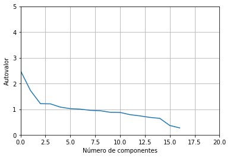

```python
plt.plot(aux[["autovalor"]].sort_values(by="autovalor",ascending=False).values)
plt.xlabel('Número de componentes')
plt.ylabel('Autovalor')
plt.xlim([0, 20])
plt.ylim([0, 5])
plt.grid()
plt.show
```

```python
kmeans = KMeans(n_clusters=3).fit(data3scale)
C = kmeans.cluster_centers_
labels = kmeans.labels_
print(C)
```

```
[[-0.06420508 -0.03475751 -0.02045663 -0.18567291 -0.21471499 -0.12099641
  -0.13437269 -0.16843852 -0.07732639  1.18133806 -0.25196517  1.02951709
  -0.02476142 -0.08853354  0.04196901  0.1179941  -0.0789154 ]
 [ 0.69884753 -0.05218545  0.23513358  1.5002181   2.22995751  2.15648357
   1.69270684  2.58463543 -0.0283755  -0.03941334  0.4928248   0.06132327
   0.49895303  0.84549667  0.06349679 -0.19858117  1.74184346]
 [-0.01805199  0.02289934 -0.00669806 -0.01268288 -0.05223916 -0.09772916
  -0.05524394 -0.10437161  0.0442876  -0.64070459  0.09989139 -0.56562437
  -0.02437406 -0.01592514 -0.02768723 -0.04922285 -0.08919094]]
```

```python
Datacopy["Cluster"] = kmeans.predict(data3scale)
```

```python
Datacopy.groupby('Cluster').size()
```

```
Cluster
0    34741
1     4825
2    63757
dtype: int64
```

```python
Datacopy.groupby('Cluster').size()
```

```
Cluster
0    34741
1     4825
2    63757
dtype: int64
```

# Ploteos

```
array([[<matplotlib.axes._subplots.AxesSubplot object at 0x0000021882C226C8>,
      dtype=object)
```

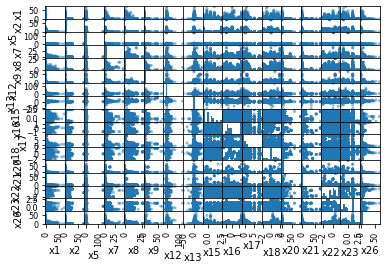

```python
pd.plotting.scatter_matrix(data3scale)
```

```python
Datacopy[["key1","key2","key3","f_corte","Cluster"]].to_excel("matriz_infromacion_clousters.xlsx")
```

Se guarda la informacion de los clusters realizados para poder cruzarla con la informacion de los productos y asi lograr hacer la segmentacion de los clientes, esto con el fin de completar matrices utilizando clientes que sean parecidos, obteniendo asi una mejor recomendacion de productos

```python
data_prd = hp.obtener_dataframe("select t1.*,cluster from proceso.base_productos_mppe as t1 inner join proceso.matriz_infromacion_clousters as t2 on key2=num_doc and key3=tipo_doc and t1.f_corte=t2.f_corte")
```

```
------------------------------------------------------------
  i    tipo    nombre    estado     hora_inicio   duracion
------------------------------------------------------------
 8/8 DATAFRAME       convirtiendo   05:58:49 PM
```

```
2022-12-09 17:59:01 - [INFO] - 11,667 filas, 158 columnas, 00:08.3 consultando, 00:01.8 descargando, 00:00.6 convirtiendo
```

```
 8/8 DATAFRAME         finalizado   05:58:49 PM     00:11.0
------------------------------------------------------------
```

```python
data_prd.info()
```

```
<class 'pandas.core.frame.DataFrame'>
RangeIndex: 11667 entries, 0 to 11666
Columns: 158 entries, llave_sistema to cluster
dtypes: int64(156), object(2)
memory usage: 14.1+ MB
```

la informacion en este caso no varia tanto entre tipos de datos ya que las variables de los productos lo que indican es la tenencia de los mismos por lo que sus valores son uno o cero

```python
data_prd.describe().T.round(4).reset_index().sort_values(by='index')
```

|  | index | count | mean | std | min | 25% | 50% | 75% | max |
| --- | --- | --- | --- | --- | --- | --- | --- | --- | --- |
| 155 | cluster | 11667.0 | 1.271400e+00 | 9.338000e-01 | 0.000000e+00 | 0.000000e+00 | 2.000000e+00 | 2.000000e+00 | 2.000000e+00 |
| 3 | f_corte | 11667.0 | 2.022080e+05 | 0.000000e+00 | 2.022080e+05 | 2.022080e+05 | 2.022080e+05 | 2.022080e+05 | 2.022080e+05 |
| 0 | llave_sistema | 11667.0 | 2.908903e+14 | 3.426402e+14 | 1.030856e+11 | 8.111415e+13 | 1.509091e+14 | 2.111231e+14 | 9.912292e+14 |
| 1 | num_doc | 11667.0 | 9.877439e+08 | 2.590001e+09 | 4.831000e+03 | 8.300713e+08 | 9.001884e+08 | 9.009284e+08 | 5.059410e+10 |
| 4 | p1 | 11667.0 | 1.507000e-01 | 3.578000e-01 | 0.000000e+00 | 0.000000e+00 | 0.000000e+00 | 0.000000e+00 | 1.000000e+00 |
| 13 | p10 | 11667.0 | 3.230000e-02 | 1.768000e-01 | 0.000000e+00 | 0.000000e+00 | 0.000000e+00 | 0.000000e+00 | 1.000000e+00 |
| 103 | p100 | 11667.0 | 1.610000e-02 | 1.259000e-01 | 0.000000e+00 | 0.000000e+00 | 0.000000e+00 | 0.000000e+00 | 1.000000e+00 |
| 104 | p101 | 11667.0 | 2.000000e-04 | 1.310000e-02 | 0.000000e+00 | 0.000000e+00 | 0.000000e+00 | 0.000000e+00 | 1.000000e+00 |
| 105 | p102 | 11667.0 | 0.000000e+00 | 0.000000e+00 | 0.000000e+00 | 0.000000e+00 | 0.000000e+00 | 0.000000e+00 | 0.000000e+00 |
| 106 | p103 | 11667.0 | 0.000000e+00 | 0.000000e+00 | 0.000000e+00 | 0.000000e+00 | 0.000000e+00 | 0.000000e+00 | 0.000000e+00 |
| 107 | p104 | 11667.0 | 0.000000e+00 | 0.000000e+00 | 0.000000e+00 | 0.000000e+00 | 0.000000e+00 | 0.000000e+00 | 0.000000e+00 |
| 108 | p105 | 11667.0 | 1.000000e-04 | 9.300000e-03 | 0.000000e+00 | 0.000000e+00 | 0.000000e+00 | 0.000000e+00 | 1.000000e+00 |
| 109 | p106 | 11667.0 | 0.000000e+00 | 0.000000e+00 | 0.000000e+00 | 0.000000e+00 | 0.000000e+00 | 0.000000e+00 | 0.000000e+00 |
| 110 | p107 | 11667.0 | 0.000000e+00 | 0.000000e+00 | 0.000000e+00 | 0.000000e+00 | 0.000000e+00 | 0.000000e+00 | 0.000000e+00 |
| 111 | p108 | 11667.0 | 0.000000e+00 | 0.000000e+00 | 0.000000e+00 | 0.000000e+00 | 0.000000e+00 | 0.000000e+00 | 0.000000e+00 |
| 112 | p109 | 11667.0 | 0.000000e+00 | 0.000000e+00 | 0.000000e+00 | 0.000000e+00 | 0.000000e+00 | 0.000000e+00 | 0.000000e+00 |
| 14 | p11 | 11667.0 | 1.527000e-01 | 3.597000e-01 | 0.000000e+00 | 0.000000e+00 | 0.000000e+00 | 0.000000e+00 | 1.000000e+00 |
| 113 | p110 | 11667.0 | 0.000000e+00 | 0.000000e+00 | 0.000000e+00 | 0.000000e+00 | 0.000000e+00 | 0.000000e+00 | 0.000000e+00 |
| 114 | p111 | 11667.0 | 0.000000e+00 | 0.000000e+00 | 0.000000e+00 | 0.000000e+00 | 0.000000e+00 | 0.000000e+00 | 0.000000e+00 |
| 115 | p112 | 11667.0 | 0.000000e+00 | 0.000000e+00 | 0.000000e+00 | 0.000000e+00 | 0.000000e+00 | 0.000000e+00 | 0.000000e+00 |
| 116 | p113 | 11667.0 | 1.180000e-02 | 1.081000e-01 | 0.000000e+00 | 0.000000e+00 | 0.000000e+00 | 0.000000e+00 | 1.000000e+00 |
| 117 | p114 | 11667.0 | 1.910000e-02 | 1.369000e-01 | 0.000000e+00 | 0.000000e+00 | 0.000000e+00 | 0.000000e+00 | 1.000000e+00 |
| 118 | p115 | 11667.0 | 5.600000e-03 | 7.440000e-02 | 0.000000e+00 | 0.000000e+00 | 0.000000e+00 | 0.000000e+00 | 1.000000e+00 |
| 119 | p116 | 11667.0 | 0.000000e+00 | 0.000000e+00 | 0.000000e+00 | 0.000000e+00 | 0.000000e+00 | 0.000000e+00 | 0.000000e+00 |
| 120 | p117 | 11667.0 | 9.000000e-04 | 2.930000e-02 | 0.000000e+00 | 0.000000e+00 | 0.000000e+00 | 0.000000e+00 | 1.000000e+00 |
| 121 | p118 | 11667.0 | 0.000000e+00 | 0.000000e+00 | 0.000000e+00 | 0.000000e+00 | 0.000000e+00 | 0.000000e+00 | 0.000000e+00 |
| 122 | p119 | 11667.0 | 5.000000e-04 | 2.270000e-02 | 0.000000e+00 | 0.000000e+00 | 0.000000e+00 | 0.000000e+00 | 1.000000e+00 |
| 15 | p12 | 11667.0 | 7.997000e-01 | 4.002000e-01 | 0.000000e+00 | 1.000000e+00 | 1.000000e+00 | 1.000000e+00 | 1.000000e+00 |
| 123 | p120 | 11667.0 | 5.200000e-03 | 7.210000e-02 | 0.000000e+00 | 0.000000e+00 | 0.000000e+00 | 0.000000e+00 | 1.000000e+00 |
| 124 | p121 | 11667.0 | 7.000000e-04 | 2.620000e-02 | 0.000000e+00 | 0.000000e+00 | 0.000000e+00 | 0.000000e+00 | 1.000000e+00 |

[output cut: 126 more lines]

al dar un primer vistaso a las variables de los productos, se pueden encontrar muchas que no contienen informacion, estas seran depuradas del dataset, por las siguientes razones:

- al utilizar el metodo de completacion de matrices, se basa que al menos uno de los registros tenga un valor en dicha variable para poder realizar la completacion
- si una variable no tiene todos sus valores en cero, realmente es una constante
- por reglas del negocio hay productos que no pueden ser obtenidos por los clientes utilizados para el estudio

```python
info = data.describe().T.round(4).reset_index().sort_values(by='index')
info.to_excel("informacion_var.xlsx")
```

```python
data_clus = data_prd.drop(["nombre_cli","segm","f_corte","llave_sistema","num_doc","p64","p16","p58","p131","p47","p137","p148","p134","p135","p136","p133","p51","p90","p67","p122","p76","p65","p63","p68","p103","p104","p102","p146","p110","p111","p109","p132","p3","p128","p97","p144","p106","p108","p107","p72","p71","p73","p150","p149","p48","p125","p126","p36","p112","p147","p50","p118","p116","tipo_doc"], axis=1)

data_clus1_pre=data_clus[data_clus ["cluster"]==1]
data_clus1=data_clus1_pre.drop(["cluster"],axis=1)
data_clus2_pre=data_clus[data_clus["cluster"]==2]
data_clus2=data_clus2_pre.drop(["cluster"],axis=1)
data_clus3_pre=data_clus[data_clus ["cluster"]==0]
data_clus3=data_clus3_pre.drop(["cluster"],axis=1)
```

se separan los clientes segun el cluster al que fueron asignados en el primer paso

```python
data_clus1.shape,data_clus2.shape,data_clus3.shape
```

```
((635, 103), (7099, 103), (3933, 103))
```

```python
E1=[]
alpha1=[]
beta1=[]
max_i1=[]
for i in range(100):
#     for j in range(10):

    modelo = NMF(n_components= 2, init='random',random_state=1982,
                alpha=(2*(i+1)/10000), beta_loss='frobenius', max_iter=(1000))
    modelo.fit_transform(data_clus1)
    alpha1.append((10*(i+1)/10000))
#     max_i1.append((1000*(j+1)))
    E1.append(modelo.reconstruction_err_)
```

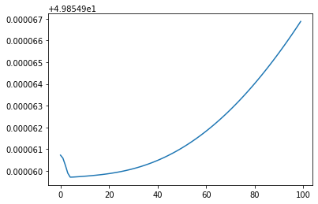

```python
plt.plot(E1)
```

- para calcular los valores optimos de los parametros, se realiza un barrido, variando estos para determinar el valor para el cual el error del modelo es mejor

```python
E1=[]
beta1=[]
max_i1=[]
for j in range(20):
    modelo = NMF(n_components= 2, init='random',random_state=1982,
                alpha=0.025, beta_loss='frobenius', max_iter=((50)*(j+1)))
    modelo.fit_transform(data_clus1)
    max_i1.append((100*(j+1)))
    E1.append(modelo.reconstruction_err_)
```

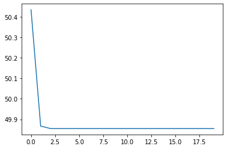

```python
plt.plot(E1)
```

De igual manera se hace para la cantidad de iteraciones que tiene el modelo para calcular la matriz completada

```python
modelo = NMF(n_components= 2, init='random',random_state=1982, alpha=0.001, beta_loss='frobenius', max_iter=250)

U = modelo.fit_transform(data_clus1)
V = modelo.components_
y= U @ V
```

con los parametros calculadas se utiliza el modelo para calcular las matrices U y V para calcular la matriz objetivo.

```python
Y=pd.DataFrame(data=y, columns=data_clus1.columns)
Y.head(1).round(4)
```

|  | p1 | p2 | p4 | p5 | p6 | p7 | p8 | p9 | p10 | p11 | p12 | p13 | p14 | p15 | p17 | p18 | p19 | p20 | p21 | p22 | p23 | p24 | p25 | p26 | p27 | p28 | p29 | p30 | p31 | … |
| --- | --- | --- | --- | --- | --- | --- | --- | --- | --- | --- | --- | --- | --- | --- | --- | --- | --- | --- | --- | --- | --- | --- | --- | --- | --- | --- | --- | --- | --- | --- |
| 0 | 0.2473 | 0.0066 | 0.0153 | 0.0032 | 0.0006 | 0.0011 | 0.2947 | 0.1369 | 0.0642 | 0.1648 | 1.102 | 0.3253 | 0.5396 | 0.8726 | 0.0004 | 0.9909 | 0.0004 | 0.0384 | 0.0341 | 0.0017 | 0.3854 | 0.0072 | 0.0006 | 0.0019 | 0.0041 | 0.0102 | 0.0038 | 0.0027 | 0.0009 | … |

los valores contenidos por los productos dira la recomendacion de que ese cliente adquiera ese producto, como no es correcto recomendar un producto que ya adquirio el cliente lo primero sera eliminar los valores que ya se conocen donde el cliente tenia el producto, para esto se crea una matriz conjugda para la suma que me permita este proceso

```python
data_clus1.head(1)
```

|  | p1 | p2 | p4 | p5 | p6 | p7 | p8 | p9 | p10 | p11 | p12 | p13 | p14 | p15 | p17 | p18 | p19 | p20 | p21 | p22 | p23 | p24 | p25 | p26 | p27 | p28 | p29 | p30 | p31 | … |
| --- | --- | --- | --- | --- | --- | --- | --- | --- | --- | --- | --- | --- | --- | --- | --- | --- | --- | --- | --- | --- | --- | --- | --- | --- | --- | --- | --- | --- | --- | --- |
| 4 | 1 | 0 | 0 | 0 | 0 | 0 | 0 | 0 | 0 | 0 | 1 | 0 | 1 | 1 | 0 | 1 | 0 | 0 | 0 | 0 | 1 | 0 | 0 | 0 | 0 | 0 | 0 | 0 | 0 | … |

```python
zeros=np.ones(data_clus1.shape)
Y1=pd.DataFrame(data=zeros, columns=data_clus1.columns)
Y2=Y1.values-data_clus1.values
Y3=pd.DataFrame(data=Y2, columns=data_clus1.columns)
```

```python
rank_clouster1=Y3*Y
rank_clouster1.head(1).round(4).rank(axis=1,ascending=False)
```

|  | p1 | p2 | p4 | p5 | p6 | p7 | p8 | p9 | p10 | p11 | p12 | p13 | p14 | p15 | p17 | p18 | p19 | p20 | p21 | p22 | p23 | p24 | p25 | p26 | p27 | p28 | p29 | p30 | p31 | … |
| --- | --- | --- | --- | --- | --- | --- | --- | --- | --- | --- | --- | --- | --- | --- | --- | --- | --- | --- | --- | --- | --- | --- | --- | --- | --- | --- | --- | --- | --- | --- |
| 0 | 91.0 | 33.0 | 25.0 | 43.0 | 66.0 | 57.5 | 2.0 | 6.0 | 12.0 | 3.0 | 91.0 | 1.0 | 91.0 | 91.0 | 74.5 | 91.0 | 74.5 | 17.0 | 19.0 | 52.5 | 91.0 | 32.0 | 66.0 | 50.0 | 37.5 | 30.0 | 40.0 | 46.5 | 61.5 | … |

por ultimo y una vez elimidados los valores para los productos ya existentes, se ordena el registo asi se tendra una lista con el producto 1 siendo el que primero se debe recomendar y en ultimo los que ya tiene y por ende son los ultimos a ofrecer, esto debido a que si un cliente ya cuenta con un producto no indica que no pueda adquir el mismo, solo que ya la necesidad esta cubierta y por ende se buscara satisfacer otra necesidad primero.

```python
E1=[]
alpha1=[]
beta1=[]
max_i1=[]
for i in range(100):
#     for j in range(10):

    modelo = NMF(n_components= 2, init='random',random_state=1982,
                alpha=((i+1)/100), beta_loss='frobenius', max_iter=(100))
    modelo.fit_transform(data_clus2)
    alpha1.append(((i+1)/1000000))
#     max_i1.append((1000*(j+1)))
    E1.append(modelo.reconstruction_err_)
```

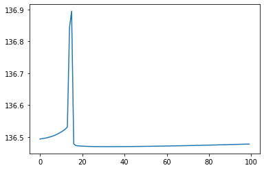

```python
plt.plot(E1)
```

```python
E1=[]
beta1=[]
max_i1=[]
for j in range(20):
    modelo = NMF(n_components= 2, init='random',random_state=1982,
                alpha=0.19, beta_loss='frobenius', max_iter=((50)*(j+1)))
    modelo.fit_transform(data_clus2)
    max_i1.append((100*(j+1)))
    E1.append(modelo.reconstruction_err_)
```

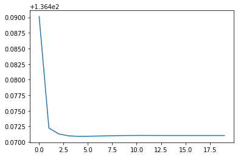

```python
plt.plot(E1)
```

```python
modelo = NMF(n_components= 2, init='random',random_state=1982, alpha=0.18, beta_loss='frobenius', max_iter=300)

U = modelo.fit_transform(data_clus2)
V = modelo.components_
y= U @ V
```

```python
Y=pd.DataFrame(data=y, columns=data_clus2.columns)
Y.head(1).round(4)
```

[output not shown]

```python
data_clus2.head(1)
```

|  | p1 | p2 | p4 | p5 | p6 | p7 | p8 | p9 | p10 | p11 | p12 | p13 | p14 | p15 | p17 | p18 | p19 | p20 | p21 | p22 | p23 | p24 | p25 | p26 | p27 | p28 | p29 | p30 | p31 | … |
| --- | --- | --- | --- | --- | --- | --- | --- | --- | --- | --- | --- | --- | --- | --- | --- | --- | --- | --- | --- | --- | --- | --- | --- | --- | --- | --- | --- | --- | --- | --- |
| 1 | 0 | 0 | 0 | 0 | 0 | 0 | 1 | 0 | 0 | 1 | 1 | 0 | 1 | 0 | 0 | 0 | 0 | 0 | 0 | 0 | 0 | 0 | 0 | 0 | 0 | 0 | 0 | 0 | 0 | … |

```python
zeros=np.ones(data_clus2.shape)
Y1=pd.DataFrame(data=zeros, columns=data_clus2.columns)
Y2=Y1.values-data_clus2.values
Y3=pd.DataFrame(data=Y2, columns=data_clus2.columns)
```

```python
rank_clouster2=Y3*Y
rank_clouster2.head(1).round(4).rank(axis=1,ascending=False)
```

[output not shown]

```python
E1=[]
alpha1=[]
beta1=[]
max_i1=[]
for i in range(100):
#     for j in range(10):

    modelo = NMF(n_components= 2, init='random',random_state=1982,
                alpha=(2*(i+1)/10000), beta_loss='frobenius', max_iter=(1000))
    modelo.fit_transform(data_clus3)
    alpha1.append((10*(i+1)/10000))
#     max_i1.append((1000*(j+1)))
    E1.append(modelo.reconstruction_err_)
```

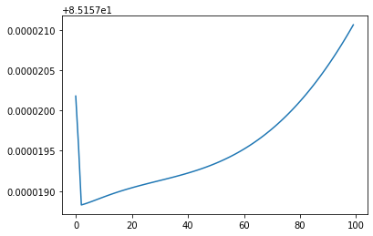

```python
plt.plot(E1)
```

```python
E1=[]
beta1=[]
max_i1=[]
for j in range(20):
    modelo = NMF(n_components= 2, init='random',random_state=1982,
                alpha=0.0006, beta_loss='frobenius', max_iter=((50)*(j+1)))
    modelo.fit_transform(data_clus3)
    max_i1.append((100*(j+1)))
    E1.append(modelo.reconstruction_err_)
```

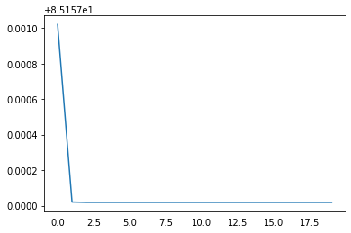

```python
plt.plot(E1)
```

```python
modelo = NMF(n_components= 2, init='random',random_state=1982, alpha=0.001, beta_loss='frobenius', max_iter=100)

U = modelo.fit_transform(data_clus3)
V = modelo.components_
y= U @ V
```

```python
Y=pd.DataFrame(data=y, columns=data_clus3.columns)
Y.head(1).round(4)
```

[output not shown]

```python
data_clus3.head(1)
```

|  | p1 | p2 | p4 | p5 | p6 | p7 | p8 | p9 | p10 | p11 | p12 | p13 | p14 | p15 | p17 | p18 | p19 | p20 | p21 | p22 | p23 | p24 | p25 | p26 | p27 | p28 | p29 | p30 | p31 | … |
| --- | --- | --- | --- | --- | --- | --- | --- | --- | --- | --- | --- | --- | --- | --- | --- | --- | --- | --- | --- | --- | --- | --- | --- | --- | --- | --- | --- | --- | --- | --- |
| 0 | 0 | 0 | 0 | 0 | 0 | 0 | 1 | 1 | 0 | 0 | 1 | 1 | 1 | 1 | 0 | 1 | 0 | 0 | 0 | 0 | 0 | 0 | 1 | 0 | 0 | 0 | 0 | 0 | 0 | … |

```python
zeros=np.ones(data_clus3.shape)
Y1=pd.DataFrame(data=zeros, columns=data_clus3.columns)
Y2=Y1.values-data_clus3.values
Y3=pd.DataFrame(data=Y2, columns=data_clus3.columns)
```

```python
rank_clouster3=Y3*Y
rank_clouster3.head(1).round(4).rank(axis=1,ascending=False)
```

[output not shown]

el proceso se realiza para cada uno de los clusters lo que hara que el comparar y recomendar productos tenga las siguientes ventajas

- Baja la complejidad para el modelo ya que este recive una matriz de menores dimenciones
- el cliente esta siendo comparado contra otros clientes que son parecidos a el no solo en terminos de productos si no en termino de las otras variables utilizadas para la clusterizacion lo que permite recomendar productos entre clientes con perfiles financieros, demograficos, de riesto y experiencia parecidos